# A Meetup with tidyJSON

John D. Smith

February 21, 2016

The tidyjson package allows more control over the json to R data extraction process than the other JSON packages offer. However, moving from the toy examples in the documentation and even the vignette to working code that etracts real data from a live API has more pitfalls and gaps than you would like. The error messages are mystifying and several crucial steps aren’t mentioned.

Here is the background documentation for this example

- [tidyjson vignette](https://cran.r-project.org/web/packages/tidyjson/vignettes/introduction-to-tidyjson.html)
- [General API documentation](http://www.meetup.com/meetup_api/docs/)
- [**Groups** record documentation](http://www.meetup.com/meetup_api/docs/find/groups/)
- [API Authorization](http://www.meetup.com/meetup_api/auth/#keysign)

## Here are the libraries used in this example:

```r
library(httr)
library(dplyr, warn.conflicts = F, quietly = T)
library(tidyjson)
library(magrittr)
library(stringr)
library(ggplot2)
```

Construct a URL and retrieve data from the API. In actual use, there is additional machinery that’s not shown here which retrieves multiple chunks, each of which has 200 records.

```r
# Get the first 200 records in page 0 of the API's data
page_num <- 0

# Retrieve the API key, which has been previously obtained and stored in the .Renviron file
meetup_api <- Sys.getenv("meetup_api")

# simplified pasting together of the URL for retrieval:
url_stub <- paste0("https://api.meetup.com/find/groups?sign=true&photo-host=public,&page=200,&key=", meetup_api)
url <- paste0(url_stub,"&offset=", page_num)

# Get a batch of data from the API
raw_contents <- GET(url = url)
```

Process the raw contents, so that tidyjson will be able to extract data from raw_contents

```r
json_raw <- httr::content(raw_contents, type = "text")
json_contents <- sub('^\\{"results":\\[', "[", json_raw)
json_contents <- sub('\\],"meta"\\:\\{.*\\}.$', "]",json_contents)
my_tbl_json <- gsub('\\\\/', "/",json_contents)  %>% as.tbl_json
```

Define several functions that will be used repeatedly to invesigate or process the json. A crucial assist was provided by [MrFlick](http://stackoverflow.com/users/2372064/mrflick) on Stack Overflow.

```r
my_spread_values <- function(x, names_list, string_type) {
  # A wrapper for "spread_values" that taks a list of names and a string type. Easier to read and much less code.
  do.call("spread_values",
    c(list(x), setNames(lapply(names_list, string_type), as.list(names_list) ) ) )
}

get_json_tbl_data_types <- function(my_tbl_json) {
# find the keys to the json, to determine which function sequence to use for retrieval
  json_data_types <- my_tbl_json %>% gather_array %>% gather_keys %>% json_types %>% group_by(key, type) %>% summarise(count = n())
  json_data_types <- ungroup(json_data_types) %>% mutate(key = as.character(key), type = as.character(type)) %>% arrange(type, key)
}

get_object_keys <- function(json_obj, object_name) {
# slightly different sequence to find the keys to an OBJECT:
  json_obj %>% gather_array %>%
  enter_object(object_name) %>% gather_keys %>% json_types %>%
  group_by(key, type) %>% summarise(count = n())
}
```

Figure out all of the keys and types of data in the json

```r
data_types <- get_json_tbl_data_types(my_tbl_json)

str_list  <- data_types  %>% filter(type == "string")  %>% select(key)
str_array  <- str_list  %>% unlist  %>% as.array
str_array
```

```
##                     key1                     key2                     key3
##                   "city"                "country"            "description"
##                     key4                     key5                     key6
##              "join_mode"                   "link" "localized_country_name"
##                     key7                     key8                     key9
##                   "name"                  "state"               "timezone"
##                    key10                    key11                    key12
##                "urlname"             "visibility"                    "who"
```

```r
num_list  <- data_types  %>% filter(type == "number")  %>% select(key)
num_array  <- num_list  %>% unlist  %>% as.array
num_array
```

```
##      key1      key2      key3      key4      key5      key6
## "created"      "id"     "lat"     "lon" "members"   "score"
```

```r
# Notice that all groups have an "organizer" object, but not all have a "category" or a "next_event"
data_types %>% filter(type != "string" & type != "number")
```

```
## Source: local data frame [6 x 3]
##
##           key   type count
##         (chr)  (chr) (int)
## 1      photos  array   149
## 2    category object   195
## 3 group_photo object   166
## 4   key_photo object     6
## 5  next_event object   179
## 6   organizer object   200
```

Now get the keys for several objects (clusters of data)

```r
cat_keys <- my_tbl_json %>% get_object_keys("category") %T>% print
```

```
## Source: local data frame [4 x 3]
## Groups: key [?]
##
##         key   type count
##       (chr) (fctr) (int)
## 1        id number   195
## 2      name string   195
## 3 shortname string   195
## 4 sort_name string   195
```

```r
org_keys <- my_tbl_json %>% get_object_keys("organizer") %T>% print
```

```
## Source: local data frame [4 x 3]
## Groups: key [?]
##
##     key   type count
##   (chr) (fctr) (int)
## 1   bio string   200
## 2    id number   200
## 3  name string   200
## 4 photo object   198
```

Now extract top-level data from the json in 2 passes, one for strings and one for numerics. To get them all in one pass would involve a hand-writing a lot of code.

```r
group_strings <- my_tbl_json %>%
  gather_array %>%
  my_spread_values(str_array, jstring ) %>%
  select(-document.id)

group_numerics <- my_tbl_json %>%
  gather_array %>%
  my_spread_values(num_array, jnumber )  %>%
  select(-document.id)
group_numerics$created <- as.POSIXct(group_numerics$created/1000, origin = "1970-01-01")
```

Could use my_spread_values inside the object “organizer”, but in this case it’s easier to just hard-code what we want. Notice the assignment statements inside the spread_values function call that we would have had to code by hand in the long list of numberics and strings above.

```r
group_organizers <- my_tbl_json %>%
  gather_array %>%
  spread_values(group_id = jnumber("id" ) ) %>%
  enter_object("organizer") %>%
  spread_values(
      organizer_id = jnumber(  "id"),
      organizer_name = jstring("name"),
      organizer_bio = jstring( "bio")
      ) %>%
    select(-array.index, -document.id )

group_category <- my_tbl_json %>%
    gather_array %>%  #gather_keys %>%
    spread_values(group_id = jnumber("id" ) ) %>%
      enter_object("category") %>%
      spread_values(
        category_id = jstring("id"),
        category_name = jstring("name"),
        category_short_name = jstring("shortname")
      ) %>%
   select(-array.index, -document.id )
```

Join it all the pieces together into a data frame that we can later use for analysis.

```r
meetup_groups <- left_join(group_strings, group_numerics, by = c("array.index" = "array.index")) %>% select(-array.index, -score)
meetup_groups <- left_join(meetup_groups, group_organizers, by = c("id" = "group_id"))
meetup_groups <- left_join(meetup_groups, group_category, by = c("id" = "group_id"))
```

Have a peek at the data

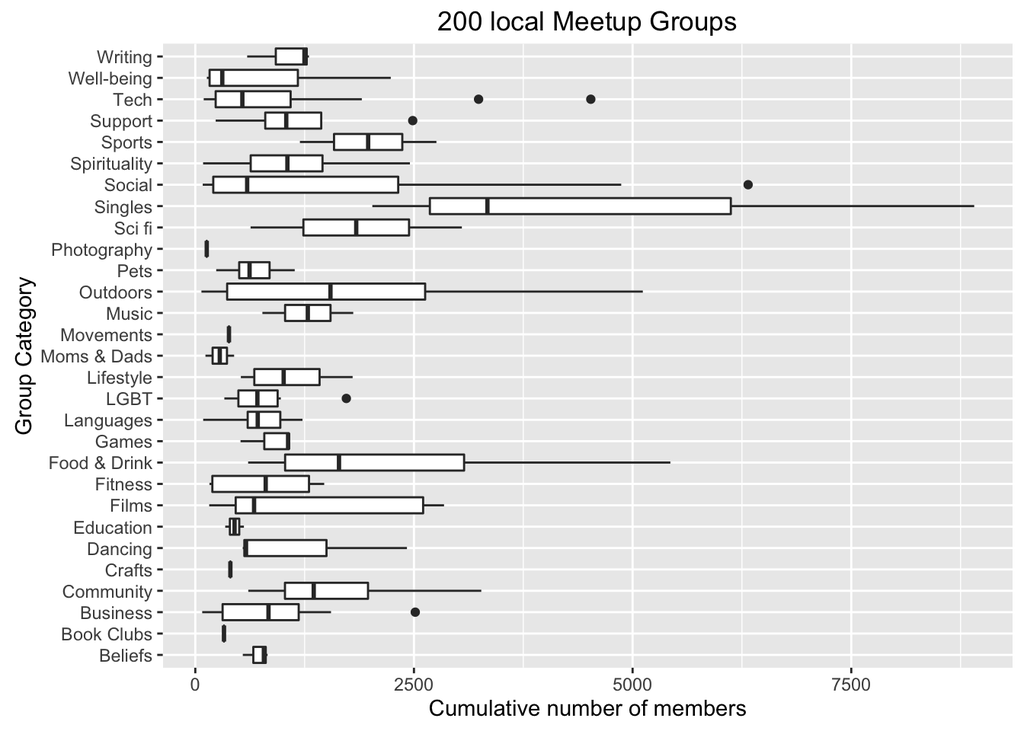

```r
ggplot(data = meetup_groups, aes(category_short_name, members)) +
  geom_boxplot() +
  coord_flip() +
  ggtitle("200 local Meetup Groups") + xlab("Group Category") + ylab("Cumulative number of members")
```